# another experiment

Evangeline Reynolds

2026-10-21

## Write scale_fill_semantic()

So we’ll use deeptime::scale_fill_geopattern as a basis, but instead of `deeptime:::geo_pattern(code)` we’ll use `llm_vec_classify(code, bigpal)`… where code is the variable to encode…

```r
bigpal <- c("plum", "coral", "darkgreen",
     "orange", "turquoise", "black",
     "dimgrey", "sienna", "maroon",
     "beige", "chartreuse", "slateblue", "pink")

library(mall)
options(.mall_chat = ellmer::chat_google_gemini())
```

```
## Using model = "gemini-2.5-flash".
```

```r
library(tidyverse)
library(deeptime)

geo_pattern
```

```
## function (code, scale = 2, col = NULL, fill = NULL, alpha = NULL,
##     bg = "white")
## {
##     img_grob <- geo_grob(code, col = col, fill = fill, alpha = alpha,
##         bg = bg)
##     scale_vp <- img_grob$children[[1]]$vp[[2]]
##     ar <- abs(diff(scale_vp$xscale))/abs(diff(scale_vp$yscale))
##     if (!is.null(scale) && !is.na(scale))
##         scale <- 2
##     img_grob$vp <- viewport(width = unit(ar * scale, "cm"), height = unit(scale,
##         "cm"))
##     pattern(img_grob, width = unit(ar * scale, "cm"), height = unit(scale,
##         "cm"), extend = "repeat")
## }
## <bytecode: 0x12c978b38>
## <environment: namespace:deeptime>
```

```r
scale_fill_translate <- function(na.value = "grey50", ...) {
  discrete_scale(
    "fill",
    palette = NULL, ...,
    na.value = na.value,
    super = ScaleDiscreteTranslate
  )
}
```

```r
vec_to_vec <- function(x, to = NULL){ifelse(x == "cat", "black", "white")}

vec_to_self <- function(x, to  = NULL){x}



translator <- function(mapped_var, to = NULL, table = NULL, how = vec_to_self) {
      if (is.na(mapped_var)) {
        na_value
      } else {
        if(is.null(table)){
          mapped_var |> how(to)
        } else {
            # lookup routine
          }


        # deeptime:::geo_pattern(code)   #<<< this is the only change
      }
    }

#' @importFrom ggplot2 ggproto ScaleDiscrete
#' @keywords internal
ScaleDiscreteTranslate <- ggproto("ScaleDiscreteTranslate", ScaleDiscrete,
  map = function(self, x, limits = self$get_limits()) {
    na_value <- if (self$na.translate) self$na.value else NA
    # clean limits
    limits <- limits[!is.na(limits)]
    # if no limits, just return a bunch of NA values
    if (length(limits) < 1) {
      return(rep(list(na_value), length(x)))
    }

    # convert to character
    if (is.factor(x)) {
      x <- as.character(x)
    }

    # filter to limits
    x[is.na(match(x, limits))] <- NA

    # get patterns
    sapply(x, translator, simplify = FALSE)
  }
)
```

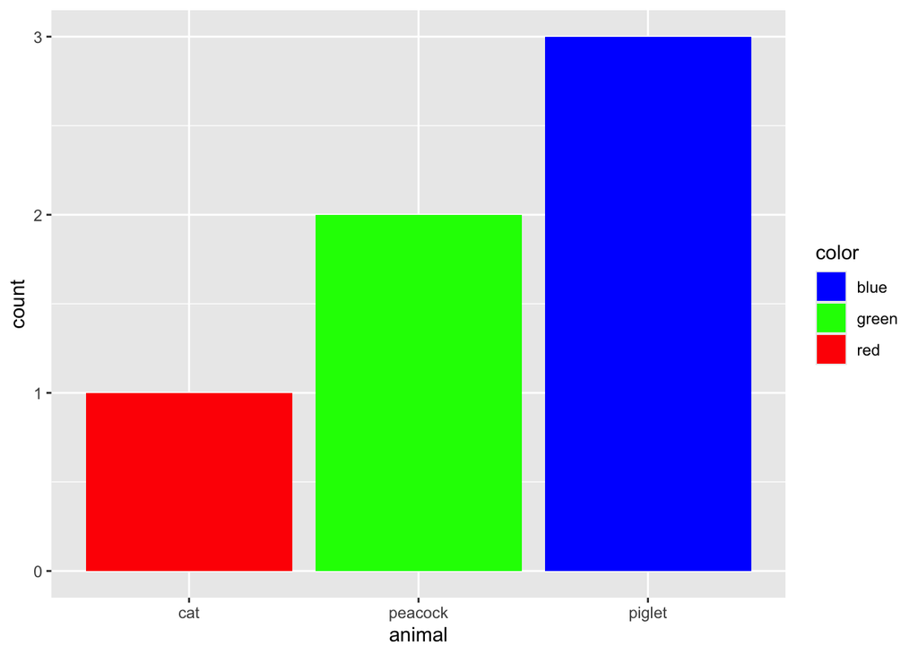

```r
tribble(~animal, ~count,~color,
        "cat",        1, "red",
        "peacock",    2, "green",
        "piglet",     3, "blue") |>
ggplot() +
  aes(fill = color,
      x = animal,
      y = count) +
  geom_col() +
  scale_fill_translate()
```

```r
layer_data()
```

```
##   x y  fill PANEL group flipped_aes ymin ymax xmin xmax colour linewidth
## 1 1 1   red     1     1       FALSE    0    1 0.55 1.45     NA       0.5
## 2 2 2 green     1     2       FALSE    0    2 1.55 2.45     NA       0.5
## 3 3 3  blue     1     3       FALSE    0    3 2.55 3.45     NA       0.5
##   linetype alpha width
## 1        1    NA   0.9
## 2        1    NA   0.9
## 3        1    NA   0.9
```

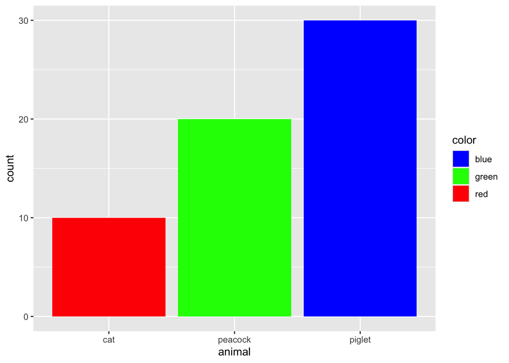

```r
tribble(~animal, ~count, ~color,
        "cat",        10, "red",
        "peacock",    20, "green",
        "piglet",    30, "blue") |>
  uncount(count) |>
  ggplot() +
  aes(fill = color,
      x = animal) +
  geom_bar() +
  scale_fill_translate()
```

```r
layer_data()
```

```
##   count prop x flipped_aes  fill PANEL group  y ymin ymax xmin xmax colour
## 1    10    1 1       FALSE   red     1     1 10    0   10 0.55 1.45     NA
## 2    20    1 2       FALSE green     1     2 20    0   20 1.55 2.45     NA
## 3    30    1 3       FALSE  blue     1     3 30    0   30 2.55 3.45     NA
##   linewidth linetype alpha width
## 1       0.5        1    NA   0.9
## 2       0.5        1    NA   0.9
## 3       0.5        1    NA   0.9
```

Hearing about @willgearty’s scale_fill_geopattern 🙌🚀🤩🙏🙏, I wondered if this is in neighboring space. I guess all scales for me look a little bit alike, because I haven’t done a ton of scale specification (I’m not color confident, which seems like a prerequisite for a lot of extension scale work).

Anyway, it seems like there’s a lookup table that scale_fill_geopattern uses which helps translate from numeric id (maybe name too) to pattern, and scale_geometry() translates from id to to boundaries (or other geometry like coordinates, paths)… Could we say that scale_fill_geopattern is a semantic encoder? (Can we say that of scale_geometry?)

And the more non-deterministic translations discussed in #151 translators from category -> color, assisted by LLMs (maybe MALL) would have a slightly different configuration, where you’d have a vector of items (menu) from which to select from instead of a lookup table.

I guess I think a scale_translate_deteministic(aesthetics = “fill, lookup_table = id_geopattern_df, etc, etc )… would deliver the appropriate translation (as scale_fill_geopattern already does).

And scale_translate_stochastic(aesthetics = “color” , to_menu = c(“olivedrab”, “bisque”, “saddlebrown”, “plum3”), translation_method = mall::llm_vec_classify, etc, etc )… would 🤞 translate aes(color = c(“frog”, “horse”)) to rendered “olivedrab” and “saddlebrown”

Maybe these scales sit between scale_identity and scale_discrete, cause that their identity is informative, and the ‘vanilla’ discrete scale ignores pretty much strips away identity?

```r
# ?ggincerta
```

```
# library(ggplot2)
# vals <- c("101", "313", "603", "733")
# ggplot(mpg, aes(factor(cyl), fill = vals[factor(cyl)])) +
#   geom_bar() +
#   scale_fill_geopattern(name = NULL)
```